```r
library(tidyverse)
options(stringsAsFactors = F)
options(scipen = 999)
th <- theme_minimal() +
  theme(title = element_text(family="Heiti TC Light"),
        text = element_text(family="Heiti TC Light"),
        axis.text.y = element_text(family="Heiti TC Light"),
        axis.text.x = element_text(family="Heiti TC Light"),
        legend.text = element_text(family="Heiti TC Light"),
        plot.title = element_text(family="Heiti TC Light")
        )
```

# Chap3 Coordination & Axis

- Chap3 Coordination & Axis [Fundamentals of Data Visualization (clauswilke.com)](https://clauswilke.com/dataviz/coordinate-systems-axes.html)

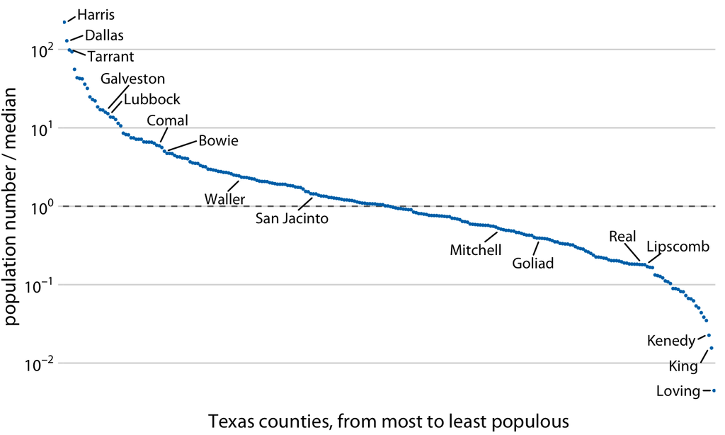

Figure 3.5: Population numbers of Texas counties relative to their median value. Select counties are highlighted by name. The dashed line indicates a ratio of 1, corresponding to a county with median population number. The most populous counties have approximately 100 times more inhabitants than the median county, and the least populous counties have approximately 100 times fewer inhabitants than the median county. Data source: 2010 Decennial U.S. Census.

- See [What’s Going On in This Graph? | Vaccination by Country](https://www.nytimes.com/2022/01/06/learning/whats-going-on-in-this-graph-jan-12-2022.html) from[What Data Shows About Vaccine Supply and Demand in the Most Vulnerable Places - The New York Times (nytimes.com)](https://www.nytimes.com/interactive/2021/12/09/world/vaccine-inequity-supply.html)

  The original chart is animated along the timeline.[What Data Shows About Vaccine Supply and Demand in the Most Vulnerable Places - The New York Times (nytimes.com)](https://www.nytimes.com/interactive/2021/12/09/world/vaccine-inequity-supply.html)

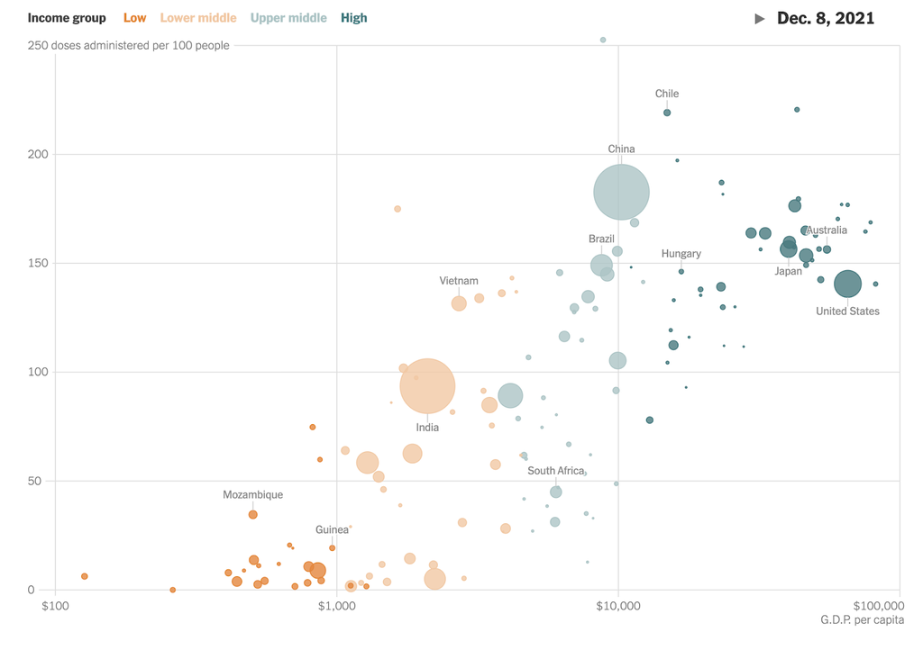

## Log-scale

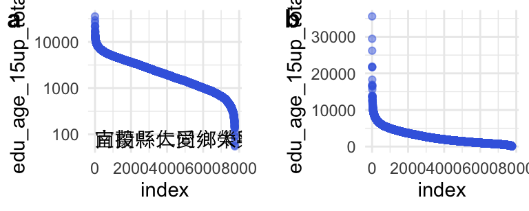

```r
raw <- read_csv("data/opendata107Y020.csv", show_col_types = FALSE)  %>%
    slice(-1) %>%
    type_convert()

toplot <- raw %>%
    select(site_id, village, edu_age_15up_total) %>%
    arrange(desc(edu_age_15up_total)) %>%
    mutate(index = row_number()) %>%
    mutate(label = ifelse(index <= 5 | index > n()-5, paste0(site_id, village), ""))

library(ggrepel)
p2 <- toplot %>% ggplot() + aes(index, edu_age_15up_total) +
    geom_point(alpha=0.5, color="royalblue") +
    geom_text_repel(aes(label = label), point.padding = .4, color = "black",
                  min.segment.length = 0, family = "Heiti TC Light") +
    theme(axis.text.x=element_blank()) +
    scale_y_log10(breaks = c(0, 1, 10, 100, 1000, 10000)) +
    theme_minimal()
p1 <- toplot %>% ggplot() + aes(index, edu_age_15up_total) +
    geom_point(alpha=0.5, color="royalblue") +
    theme(axis.text.x=element_blank()) +
    theme_minimal()

cowplot::plot_grid(
  p2, NULL, p1,
  labels = c("a", "", "b"), nrow = 1, rel_widths = c(1, 0.1, 1)
)
```

## Square-root scale

Chap3 Coordination & Axis [Fundamentals of Data Visualization (clauswilke.com)](https://clauswilke.com/dataviz/coordinate-systems-axes.html)

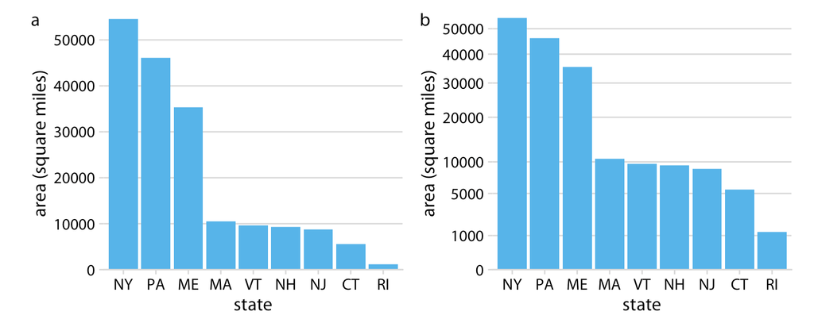

Figure 3.8: Areas of Northeastern U.S. states. (a) Areas shown on a linear scale. (b) Areas shown on a square-root scale. Data source: Google.

前面是視覺化了各村里大於十五歲以上人口的人口數分佈，採用對數尺度（log-scale）可以觀察到比較小的村里。那有什麼是適合用平方根尺度（sqrt-scale）的呢？是土地嗎？密度嗎？還是人口數？是村里等級嗎？鄉鎮市區等級嗎？還是縣市等級？

```r
town <- read_csv("data/tw_population_opendata110N010.csv") %>%
    slice(-1, -(370:375)) %>%
    type_convert()
```

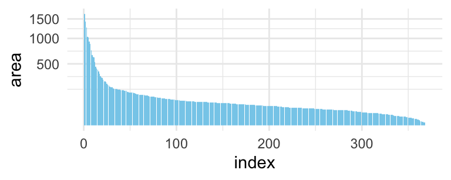

```r
town %>%
    arrange(desc(area)) %>%
    mutate(index = row_number()) %>%
    ggplot() + aes(index, area) %>%
    geom_col(fill="skyblue") +
    scale_y_sqrt() +
    theme_minimal()
```

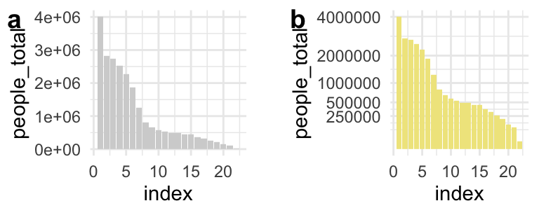

```r
county <- town %>%
    mutate(county = str_sub(site_id, 1, 3)) %>%
    group_by(county) %>%
    summarize(
        area = sum(area),
        people_total = sum(people_total)
    ) %>%
    ungroup()

p1 <- county %>%
    arrange(desc(people_total)) %>%
    mutate(index = row_number()) %>%
    ggplot() + aes(index, people_total) %>%
    geom_col(fill="lightgrey") +
    # scale_y_sqrt() +
    theme_minimal()

p2 <- county %>%
    arrange(desc(people_total)) %>%
    mutate(index = row_number()) %>%
    ggplot() + aes(index, people_total) %>%
    geom_col(fill="khaki") +
    scale_y_sqrt(breaks=c(0, 250000, 500000, 1000000, 2000000, 4000000)) +
    theme_minimal()

cowplot::plot_grid(
  p1, NULL, p2,
  labels = c("a", "", "b"), nrow = 1, rel_widths = c(1, 0.1, 1)
)
```

# TW-Salary (boxplot)

Inspired by [Six Myths About Choosing a College Major - The New York Times (nytimes.com)](https://www.nytimes.com/2017/11/03/education/edlife/choosing-a-college-major.html) and [What’s Going On in This Graph? | Jan. 9, 2018 - The New York Times (nytimes.com)](https://www.nytimes.com/2018/01/04/learning/whats-going-on-in-this-graph-jan-9-2018.html)

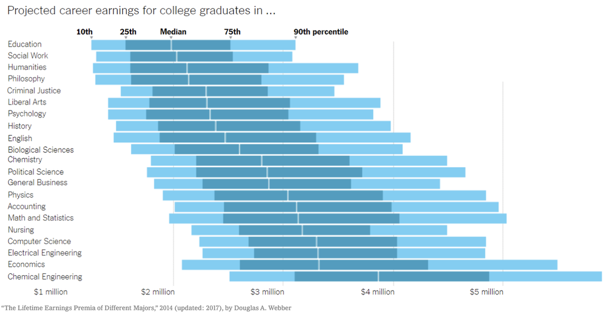

```r
library(readxl)
raw <- read_excel("data/tw_salary109.xlsx", sheet=1, trim_ws = T)
raw
```

```
## # A tibble: 29 × 5
##    Category        Q1 Median    Q3  Mean
##    <chr>        <dbl>  <dbl> <dbl> <dbl>
##  1 　男          39     53.2  82.3  70.7
##  2 　女          35.1   46.8  67.6  58.6
##  3 　未滿25歲    28.1   35.8  45.1  37.7
##  4 　25-29歲     36.6   47.8  61.7  53
##  5 　30-39歲     39.2   53.3  77    64.1
##  6 　40-49歲     39.9   56.9  91.8  74.8
##  7 　50-64歲     37.8   53.3  88.4  75.5
##  8 　65歲以上    30.6   40.9  63.1  62.6
##  9 　國中及以下  32.7   40.5  52    45.4
## 10 　高中（職）  34.5   44.7  59.8  51.9
## # … with 19 more rows
```

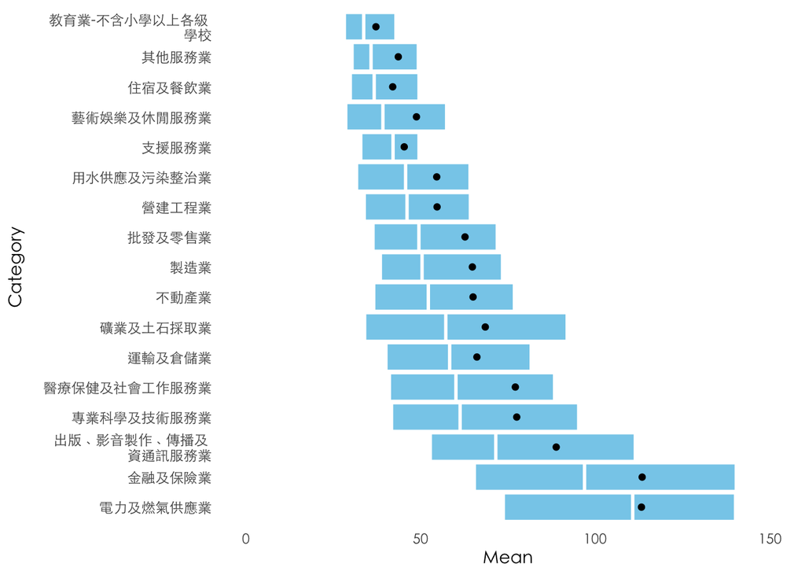

```r
raw %>%
    slice(-(1:12)) %>%
    mutate(Category = reorder(Category, desc(Median))) %>%
    ggplot() + aes(y = Category,
                   xlower=Q1, xmiddle=Median, xupper=Q3, xmin=0, xmax=150) +
    geom_boxplot(stat = "identity", color="white", fill="skyblue") +
    geom_point(aes(x = Mean)) +
    th +
    theme(panel.grid.minor = element_blank(),
          panel.grid.major = element_blank())
```

# TW-Income (boxplot)

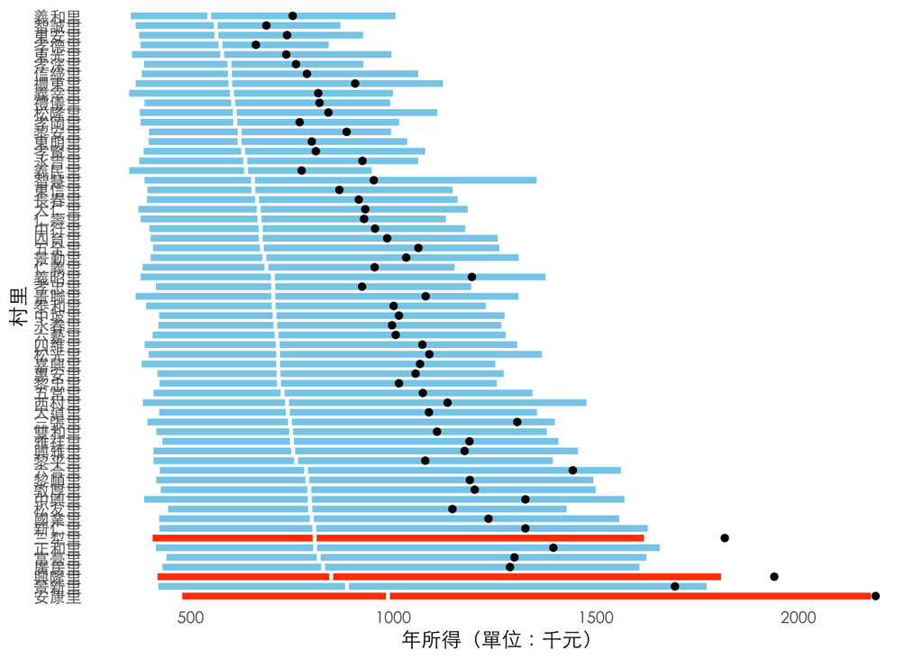

```r
library(gghighlight)
toplot <- read_csv("data/tw_income_107.csv", ) %>%
    filter(!`村里` %in% c("合計", "其他", "福住里")) %>%
    filter(鄉鎮市區 %in% c("信義區")) %>%
    mutate(村里 = reorder(村里, desc(中位數)))

toplot %>%
    mutate(group = if_else((平均數>第三分位數), "highlight", "none")) %>%
    ggplot() + aes(y = 村里,
                   xlower=第一分位數, xmiddle=中位數, xupper=第三分位數,
                   xmin= min(第一分位數), xmax=max(第三分位數), fill=group) +
    geom_boxplot(stat = "identity", color="white") +
    scale_fill_manual(values = c("highlight"="orangered", "none"="skyblue")) + guides(fill=FALSE) +
    geom_point(aes(x = 平均數)) +
    xlab("年所得（單位：千元）") +
    th +
    theme(panel.grid.minor = element_blank(),
          panel.grid.major = element_blank())
```